# Tutorial 2

Intro Data Science for Health and Social Care Week 3

Ahmed SOROUR

07-10-2023

Welcome to this tutorial paired-programming practice document!

In pairs, work through this document. A sample completed document will available under the Week 3 Tutorial folder on Learn as well.

# Task 0

Before getting started, I have a sneaky Task 0 for you. Load the R Markdown Quick Reference Guide by clicking the “Help” tab at the top of your screen and put your names in the author element of the YAML instead of mine.

# Tasks for Markdown Tutorial Practice

## Task 1

Install the following packages if you do not already have them already, and load them with the `library()` function

- tidyverse
- prettydoc
- rmdformats
- gapminder
- knitr
- kableExtra

```r
# your code here:
options(repos = "https://cran.rstudio.com/")
utils::install.packages("tidyverse")
```

```
##
##  C:\Users\soroura\AppData\Local\Temp\Rtmps7y1D4\downloaded_packages
```

```r
utils::install.packages("prettydoc")
```

```
##
##  C:\Users\soroura\AppData\Local\Temp\Rtmps7y1D4\downloaded_packages
```

```r
utils::install.packages("rmdformats")
```

```
##
##  C:\Users\soroura\AppData\Local\Temp\Rtmps7y1D4\downloaded_packages
```

```r
utils::install.packages("gapminder")
```

```
##
##  C:\Users\soroura\AppData\Local\Temp\Rtmps7y1D4\downloaded_packages
```

```r
utils::install.packages("knitr")
```

```
##
##  C:\Users\soroura\AppData\Local\Temp\Rtmps7y1D4\downloaded_packages
```

```r
utils::install.packages("kableExtra")
```

```
##
##  C:\Users\soroura\AppData\Local\Temp\Rtmps7y1D4\downloaded_packages
```

```r
library(tidyverse)
library(prettydoc)
library(rmdformats)
library(gapminder)
library(knitr)
library(kableExtra)
```

### Task 1.2

If you knit the file after having included the code in Task 1 to load the libraries, you will notice that printed out are some messages from the packages being loaded. You can prevent this from happening with the `message = FALSE` code chunk option. Add this to your `task-1` code chunk above and knit the file again to see the difference.

## Task 2

We are using the gapminder dataset, which we can load from the `gapminder` package by calling the function `gapminder`. Save the data into an object called `gap_data` and find out more about the dataset by pulling up its documentation using the `?` function we learned about in last week’s tutorial.

```r
#your code here
gap_data <- gapminder
?gapminder
```

```
## starting httpd help server ... done
```

## Task 3

Now that we have `gap_data` saved to our global environment, pick a few functions to check what the data looks like and what variables we have to work with.

```r
# your code here
summary(gapminder)
```

```
##         country        continent        year         lifeExp
##  Afghanistan:  12   Africa  :624   Min.   :1952   Min.   :23.60
##  Albania    :  12   Americas:300   1st Qu.:1966   1st Qu.:48.20
##  Algeria    :  12   Asia    :396   Median :1980   Median :60.71
##  Angola     :  12   Europe  :360   Mean   :1980   Mean   :59.47
##  Argentina  :  12   Oceania : 24   3rd Qu.:1993   3rd Qu.:70.85
##  Australia  :  12                  Max.   :2007   Max.   :82.60
##  (Other)    :1632
##       pop              gdpPercap
##  Min.   :6.001e+04   Min.   :   241.2
##  1st Qu.:2.794e+06   1st Qu.:  1202.1
##  Median :7.024e+06   Median :  3531.8
##  Mean   :2.960e+07   Mean   :  7215.3
##  3rd Qu.:1.959e+07   3rd Qu.:  9325.5
##  Max.   :1.319e+09   Max.   :113523.1
##
```

```r
dim(gapminder)
```

```
## [1] 1704    6
```

```r
names(gapminder)
```

```
## [1] "country"   "continent" "year"      "lifeExp"   "pop"       "gdpPercap"
```

```r
unique(gap_data$country)
```

```
##   [1] Afghanistan              Albania                  Algeria
##   [4] Angola                   Argentina                Australia
##   [7] Austria                  Bahrain                  Bangladesh
##  [10] Belgium                  Benin                    Bolivia
##  [13] Bosnia and Herzegovina   Botswana                 Brazil
##  [16] Bulgaria                 Burkina Faso             Burundi
##  [19] Cambodia                 Cameroon                 Canada
##  [22] Central African Republic Chad                     Chile
##  [25] China                    Colombia                 Comoros
##  [28] Congo, Dem. Rep.         Congo, Rep.              Costa Rica
##  [31] Cote d'Ivoire            Croatia                  Cuba
##  [34] Czech Republic           Denmark                  Djibouti
##  [37] Dominican Republic       Ecuador                  Egypt
##  [40] El Salvador              Equatorial Guinea        Eritrea
##  [43] Ethiopia                 Finland                  France
```

[output cut: 34 more lines]

```r
table(gap_data$continent)
```

```
##
##   Africa Americas     Asia   Europe  Oceania
##      624      300      396      360       24
```

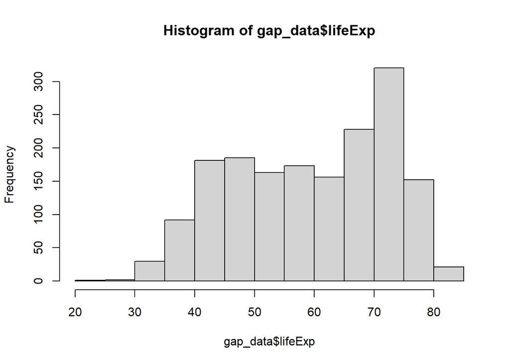

```r
hist(gap_data$lifeExp)
```

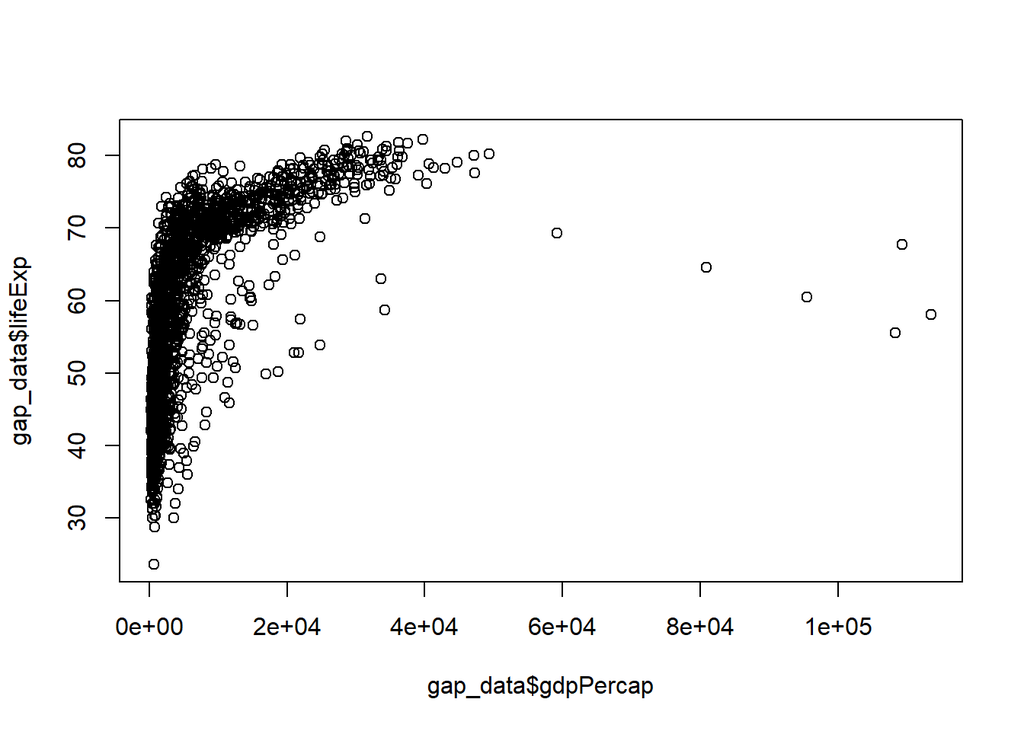

```r
plot(gap_data$gdpPercap, gap_data$lifeExp)
```

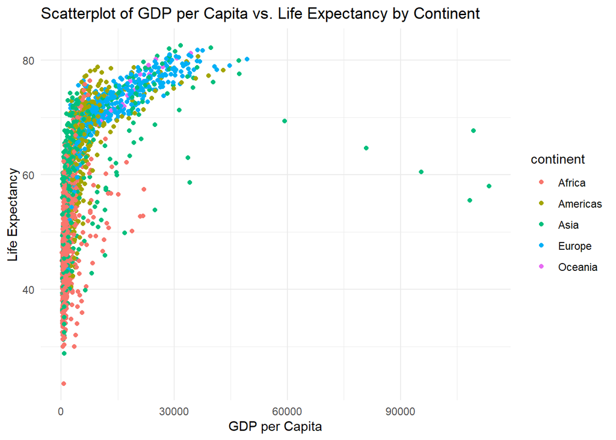

```r
# Load the ggplot2 package if not already loaded
library(ggplot2)

# Create the scatterplot using ggplot2
# Load the ggplot2 package if not already loaded
library(ggplot2)

# Create the colorful scatterplot using ggplot2
ggplot(data = gap_data, aes(x = gdpPercap, y = lifeExp, color = continent)) +
  geom_point() +
  labs(x = "GDP per Capita", y = "Life Expectancy") +
  ggtitle("Scatterplot of GDP per Capita vs. Life Expectancy by Continent") +
  theme_minimal()
```

## Task 4

When making tables, it is a good idea to use the `kable()` function from the `knitr` package to produce nice looking tables rather than the usual r output.

Run the code below to see the output:

```r
gap_data %>%
  select(-pop) %>%
  sample_n(10)
```

```
## # A tibble: 10 × 5
##    country            continent  year lifeExp gdpPercap
##    <fct>              <fct>     <int>   <dbl>     <dbl>
##  1 Benin              Africa     1997    54.8     1233.
##  2 Mexico             Americas   2002    74.9    10742.
##  3 Guinea-Bissau      Africa     2002    45.5      576.
##  4 Guinea-Bissau      Africa     2007    46.4      579.
##  5 West Bank and Gaza Asia       1982    64.4     4336.
##  6 Afghanistan        Asia       1977    38.4      786.
##  7 Morocco            Africa     1987    62.7     2755.
##  8 Iraq               Asia       1952    45.3     4130.
##  9 Mauritius          Africa     1987    68.7     4784.
## 10 Australia          Oceania    1957    70.3    10950.
```

Copy the code above and add a pipe with the `kable()` function and knit the file, comparing the two outputs. Which do you prefer?

```r
# your code here
gap_data %>%
  select(-pop) %>%
  sample_n(10) %>%
  kable()
```

| country | continent | year | lifeExp | gdpPercap |
| --- | --- | --- | --- | --- |
| Central African Republic | Africa | 1977 | 46.775 | 1109.3743 |
| Switzerland | Europe | 1992 | 78.030 | 31871.5303 |
| Guinea-Bissau | Africa | 1997 | 44.873 | 796.6645 |
| Sierra Leone | Africa | 1982 | 38.445 | 1465.0108 |
| Indonesia | Asia | 1992 | 62.681 | 2383.1409 |
| Jordan | Asia | 2007 | 72.535 | 4519.4612 |
| Morocco | Africa | 1957 | 45.423 | 1642.0023 |
| Bulgaria | Europe | 2007 | 73.005 | 10680.7928 |
| Bosnia and Herzegovina | Europe | 1962 | 61.930 | 1709.6837 |
| Chad | Africa | 1972 | 45.569 | 1104.1040 |

For further styling options, the [`kableExtra` package](https://haozhu233.github.io/kableExtra/awesome_table_in_html.html#Overview) can help!

*Note:* Knit the document to see how the code above becomes a hyperlink in the knitted report - so useful!

When using an HTML document/table, even just including one more line of code significantly improves the formatting. There are 6 additional alternative HTML table theme options apart from the default bootstrap theme:

- `kable_styling()` for the bootstrap theme
1. `kable_classic()`
2. `kable_classic2()`
3. `kable_paper()`
4. `kable_minimal()`
5. `kable_material()`
6. `kable_material_dark()`

*Note:* The majority of `kableExtra` functions will work in [both HTML and PDF knitted files](https://github.com/haozhu233/kableExtra#basic-usage). When using a PDF file, you need to use the argument `latex_options` instead as you are producing LaTeX tables. When using `kableExtra` functions, it is recommended by the package authors to use the wrapper function `kbl()` instead of `kable()`. Pull up the documentation of `kbl()` with the using the `?` function to learn more.

## Task 5

Explore some of the `kableExtra` styling options and further customize the table output, stilling knitting to HTML

```r
# your code here
gap_data %>%
  select(-pop) %>%
  sample_n(10) %>%
  kable() %>%
  kable_styling()
```

| country | continent | year | lifeExp | gdpPercap |
| --- | --- | --- | --- | --- |
| Poland | Europe | 2002 | 74.670 | 12002.2391 |
| Slovenia | Europe | 1967 | 69.180 | 9405.4894 |
| Sao Tome and Principe | Africa | 1997 | 63.306 | 1339.0760 |
| Equatorial Guinea | Africa | 1997 | 48.245 | 2814.4808 |
| Serbia | Europe | 1982 | 70.162 | 15181.0927 |
| Congo, Dem. Rep. | Africa | 1977 | 47.804 | 795.7573 |
| Zambia | Africa | 2002 | 39.193 | 1071.6139 |
| Zambia | Africa | 1952 | 42.038 | 1147.3888 |
| Finland | Europe | 1957 | 67.490 | 7545.4154 |
| Bosnia and Herzegovina | Europe | 1957 | 58.450 | 1353.9892 |

## Task 6

You can easily integrate figures into your report as well using a code chunk dedicated to the figure of interest. We have provided some example figure code below so you can see how figure seamlessly integrate into the knitted report.

Un-comment (delete the #) in the code below and knit the file.

*Hint:* One of the most useful keyboard shortcuts I use in my own coding to edit multiple lines of code at one time is to elongate the cursor by holding down the `alt` (on a Mac `option`) key then click and drag the cursor down as far as you would like to go. Try this to delete the comments rather than clicking on each line individually

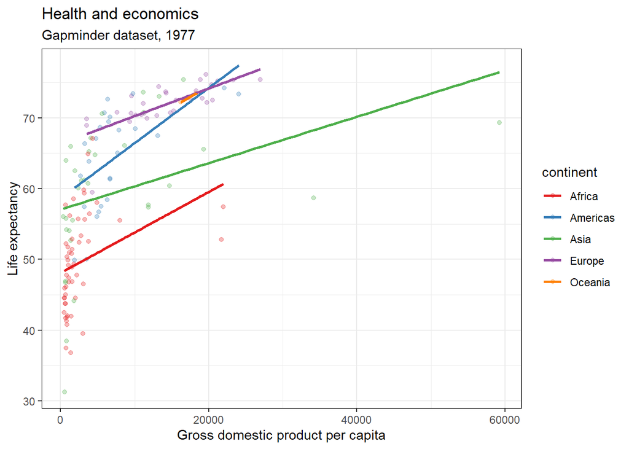

```r
gap_data %>%
 filter(year == 1977) %>%
 ggplot(aes(y = lifeExp, x = gdpPercap, colour = continent)) +
 geom_point(alpha = 0.3) +
 theme_bw() +
 geom_smooth(method = "lm", se = FALSE) +
 scale_colour_brewer(palette = "Set1") +
 labs(x = "Gross domestic product per capita",
      y = "Life expectancy",
      title = "Health and economics",
      subtitle = "Gapminder dataset, 1977")
```

## Task 7

In some reports you may also wish to include images related to the your stakeholders or other information beyond data visualisation. You can easily insert images into your R Markdown file either from a webpage or from a file in the same directory:

1. From a webpage

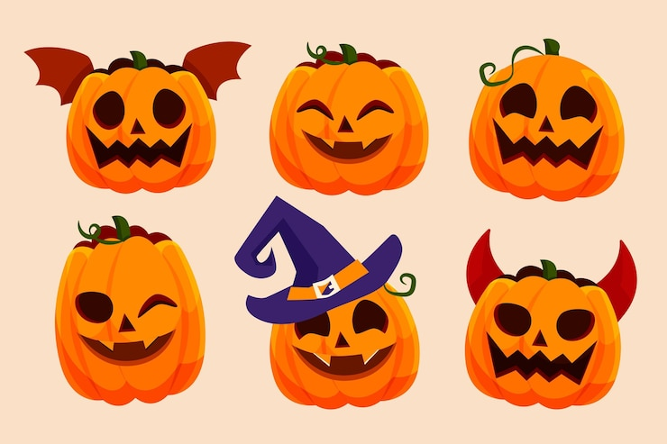

To get the link to a picture from a webpage go to your internet browser of choice, Images, and right click on the image and select “Copy Image Link”.

2. From a file

*Note:* the code below will work only if you have the PNG file saved in a folder called figures in your workspace.

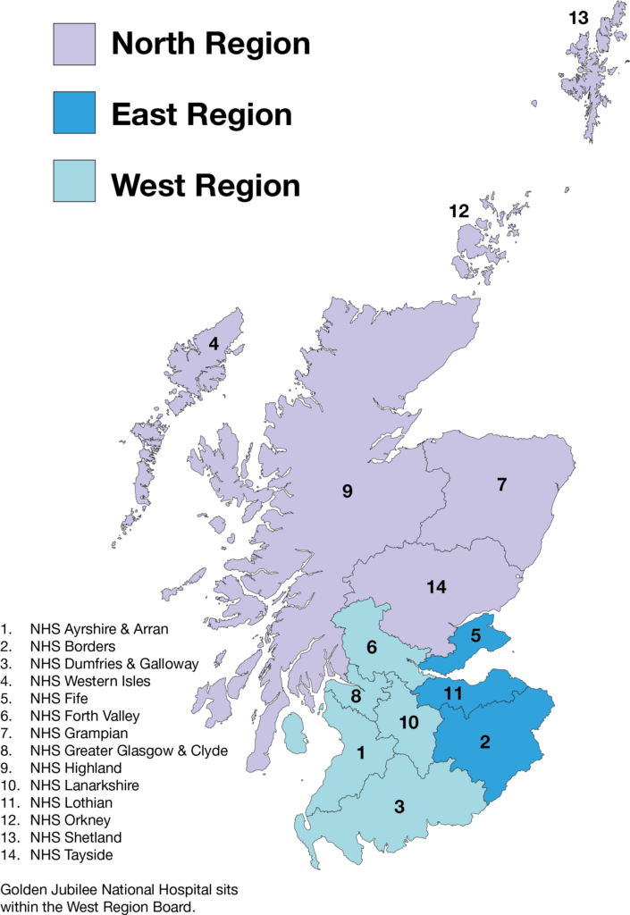

NHS Scotland Health Boards

Try to include an image of your choosing either from a saved file or a webpage.

## Task 8

You can also use r code directly in text. For example:

> There are 1704 observations in the data set.

*Note:* above I have put the inline code as a blockquote just to make it standout when the file is knitted. This is not required for inline code.

This can be an incredible time saver if you are creating a report where the data itself might still be coming in. Rather than needing to manually update descriptive information such as how many observations there are in the data set, let R do it for you!

Why don’t you try to write your own inline code in the following statement

The gapminder dataset has variables with the following names: ** country, continent, year, lifeExp, pop, gdpPercap**

# Functionalities of different output formats

## HTML

In general, I find that when knitting to an `html_document` there are more interesting functionalities. Indeed, Markdown was originally designed for HTML output so the HTML format has the richest features.

- floating table of contents
- code download output option
- code folding (hide or show)
- tabbed sections

You can have a look at some of the other options when knitting to HTML in the [HTML document chapter in R Markdown: The Definitive Guide](https://bookdown.org/yihui/rmarkdown/html-document.html#appearance-and-style)

Chunk names are not necessarily required to knit, but are good practice and help to support more advanced knitted approaches. Chunk labels should be

- unique
- do not use spaces, rather use dashes (-)
- use alphanumeric characters (a-z, A-Z and 0-9), because they are not special characters and will surely work for all output formats
- spaces and underscores in particular, may cause trouble in certain packages, such as `bookdown`

We do not cover the `bookdown` package as part of this course, but it extends the functionality of RMarkdown to allow for figures and tables to be easily cross-referenced within your text (among other things).

### Task 9

Look through some of the different customisation options and customise the HTML report. You may not get to this task in the tutorial, in which case try it on your own and have a look at the sample completed RMD file to see some examples of different ways to customize, including the very cool code fold option!

## PDF

PDFs in R Markdown also have a variety of features, but not nearly as many as HTML documents. To find out more, check out the [PDF document chapter in R Markdown: The Definitive Guide](https://bookdown.org/yihui/rmarkdown/pdf-document.html)

## Word

The most notable feature of Word documents in R Markdown is the ability to create a “style reference document”. To find out more, including a short video on how to create and use a reference document, check out the [Word document chapter in R Markdown: The Defintive Guide](https://bookdown.org/yihui/rmarkdown/word-document.html)

## Themes

In general, there are a [variety of theme options available](https://www.datadreaming.org/post/r-markdown-theme-gallery/) to use with R Markdown HTML documents

### `prettydoc`

The `prettydoc` package includes a variety of other theme options when knitting to HTML: https://prettydoc.statr.me/index.html

Once you have installed the package, you can open a prettydoc formatted document from “From Template” tab when choosing to create a new R Markdown file.

To use a `prettydoc` theme not from a template, you need to edit the YAML accordingly:

```
`output:
    prettydoc::html_pretty:
    theme: cayman`
```

*Note:* When using `html_pretty` engine for themes, `code_folding`, `code_download`, and `toc_float` are not applicable.

### `rmdformats`

The `rmdformats` package includes a variety of other theme options when knitting to HTML: https://github.com/juba/rmdformats. Some themes allow for things like a dynamic table of contents, but not all of them. See the “Features matrix” table on the above webpage for more info.

Similar to above, once you have installed the package, you can open a rmdformts formatted document from “From Template” tab when choosing to create a new R Markdown file.

To use a `rmdformats` theme not from template, you need to edit the YAML accordingly:

```
`output:
    rmdformats::robobook`
```

### Task 10

Choose a few different theme options and update the YAML accordingly.

# Reproducibility!

In practice, depending on your audience, you will need to decide to show your code or not. It is unlikely that you will want to show the code used to produce your analysis, tables, or figures to an audience unfamiliar with R and would therefore set `echo = FALSE` in the set-up chunk. For this course, though, and in particular for the datathon report, you will need to set `echo=TRUE` so that we can see your code and the product of that code.

While it can take up space, it is good practice to finish a document calling the `sessionInfo` function, which lists all of the packages you used, their versions, and more.

[session information not shown]

*Dr. Brittany Blankinship (2023)*